# Practical Machine Learning: Prediction Assignment Writeup

Livan Alonso

January 23, 2015

## Background

The goal of this project is to predict the manner in which 6 participants did the exercise. Six young health participants were asked to perform one set of 10 repetitions of the Unilateral Dumbbell Biceps Curl in five different fashions: exactly according to the specification (Class A), throwing the elbows to the front (Class B), lifting the dumbbell only halfway (Class C), lowering the dumbbell only halfway (Class D) and throwing the hips to the front (Class E). The data was collected from accelerometers on the belt, forearm, arm, and dumbell of participants. More information is available from the website here: http://groupware.les.inf.puc-rio.br/har (see the section on the Weight Lifting Exercise Dataset).

### Reading files

```r
training<-read.csv("training.csv",header = TRUE,na.strings=c("#DIV/0!","","NA"))
testing<-read.csv("testing.csv",header = TRUE,na.strings=c("#DIV/0!","","NA"))
```

### Data Preprocessing and Transformation

Split the orginal training data in two datasets subtraining and subtesting.

The simple first step in looking at the data include finding missing values. The collected data corresponds to measurements of 160 variables, however 100 variables contains numerous missing values (more than 95% of measurements are NA values). The data was subset based on this analysis. The new training and testing data subsets does not contain missing values (60 variables).

```r
feature.Nna<-colSums((!is.na(subtraining)*1))/dim(subtraining)[[1]]
list.features<-names(feature.Nna)[as.numeric(feature.Nna)>0.5] ## the cutoff value provides same results  [0.05 to 1]
dim(subtraining)[[2]]-length(list.features) ##
```

```
## [1] 100
```

```r
newtraining<-subtraining[,list.features]
dim(newtraining)
```

```
## [1] 11776    60
```

The next step is to remove those variables that have very little variability. The nearZeroVar function can be used to identify those variables, which likely would not be good predictors (also, index column was removed ). It can be noticed that we have reduced the number of variables to 58.

```r
nzv<-nearZeroVar(newtraining,saveMetrics=TRUE)
list.nzv<-rownames(nzv)[nzv$nzv==TRUE]
dim(newtraining)[2]-length(list.nzv)-1
```

```
## [1] 58
```

```r
list.nzv<-c("X",list.nzv)
newtraining<-newtraining[!names(newtraining) %in% list.nzv]
dim(newtraining)
```

```
## [1] 11776    58
```

By simple exploratory data analysis, it can be noticed that variables, such as: user_name,raw_timestamp_part_1,raw_timestamp_part_2 and cvtd_timestamp should not be part of our predictors.

```r
rem.variables<-c("user_name","raw_timestamp_part_1","raw_timestamp_part_2","cvtd_timestamp")
newtraining<-newtraining[,!names(newtraining) %in% rem.variables]
dim (newtraining)
```

```
## [1] 11776    54
```

```r
col.newtraining<-names(newtraining)
newtesting<-subtesting[col.newtraining]
```

## Testing different classification algoritms

### Predicting with trees

```r
library(rpart)
modFitTree<-rpart(classe~.,data=newtraining,method="class")
predTree<-predict(modFitTree,newdata=newtesting,type="class")

#Confusion matrix was calculated to visualize the performance of the algoritms.

confusionMatrix(predTree,subtesting$classe)
```

```
## Confusion Matrix and Statistics
##
##           Reference
## Prediction    A    B    C    D    E
##          A 1928   98    3   16    5
##          B  150 1173   88  110   74
##          C    1   92 1144   50    8
##          D  131   66  113  980   62
##          E   22   89   20  130 1293
##
## Overall Statistics
##
##                Accuracy : 0.8307
##                  95% CI : (0.8223, 0.839)
##     No Information Rate : 0.2845
##     P-Value [Acc > NIR] : < 2.2e-16
##
##                   Kappa : 0.7865
##  Mcnemar's Test P-Value : < 2.2e-16
##
## Statistics by Class:
##
##                      Class: A Class: B Class: C Class: D Class: E
## Sensitivity            0.8638   0.7727   0.8363   0.7621   0.8967
## Specificity            0.9783   0.9333   0.9767   0.9433   0.9592
## Pos Pred Value         0.9405   0.7354   0.8834   0.7249   0.8320
## Neg Pred Value         0.9476   0.9448   0.9658   0.9529   0.9763
## Prevalence             0.2845   0.1935   0.1744   0.1639   0.1838
## Detection Rate         0.2457   0.1495   0.1458   0.1249   0.1648
## Detection Prevalence   0.2613   0.2033   0.1651   0.1723   0.1981
## Balanced Accuracy      0.9210   0.8530   0.9065   0.8527   0.9280
```

```r
library(rattle)
```

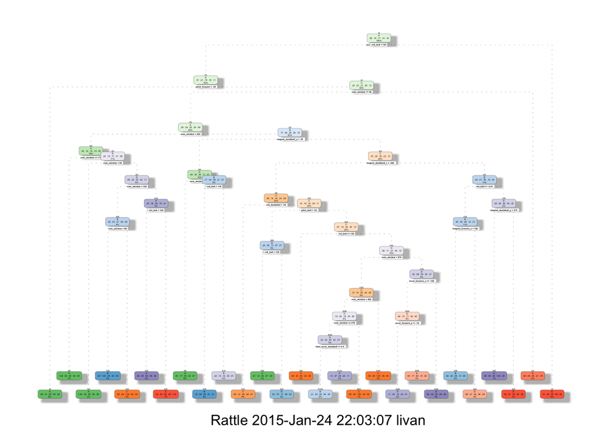

```r
fancyRpartPlot(modFitTree)
```

### Predicting with random forest

```r
library(randomForest)
modFitRF<-randomForest(classe~.,data=newtraining,method="class")
predRF<-predict(modFitRF,newdata=newtesting,type="class")
confusionMatrix(predRF,newtesting$classe)
```

```
## Confusion Matrix and Statistics
##
##           Reference
## Prediction    A    B    C    D    E
##          A 2232    2    0    0    0
##          B    0 1515    6    0    0
##          C    0    1 1362   11    0
##          D    0    0    0 1274    7
##          E    0    0    0    1 1435
##
## Overall Statistics
##
##                Accuracy : 0.9964
##                  95% CI : (0.9948, 0.9976)
##     No Information Rate : 0.2845
##     P-Value [Acc > NIR] : < 2.2e-16
##
##                   Kappa : 0.9955
##  Mcnemar's Test P-Value : NA
##
## Statistics by Class:
##
##                      Class: A Class: B Class: C Class: D Class: E
## Sensitivity            1.0000   0.9980   0.9956   0.9907   0.9951
## Specificity            0.9996   0.9991   0.9981   0.9989   0.9998
## Pos Pred Value         0.9991   0.9961   0.9913   0.9945   0.9993
## Neg Pred Value         1.0000   0.9995   0.9991   0.9982   0.9989
## Prevalence             0.2845   0.1935   0.1744   0.1639   0.1838
## Detection Rate         0.2845   0.1931   0.1736   0.1624   0.1829
## Detection Prevalence   0.2847   0.1939   0.1751   0.1633   0.1830
## Balanced Accuracy      0.9998   0.9985   0.9969   0.9948   0.9975
```

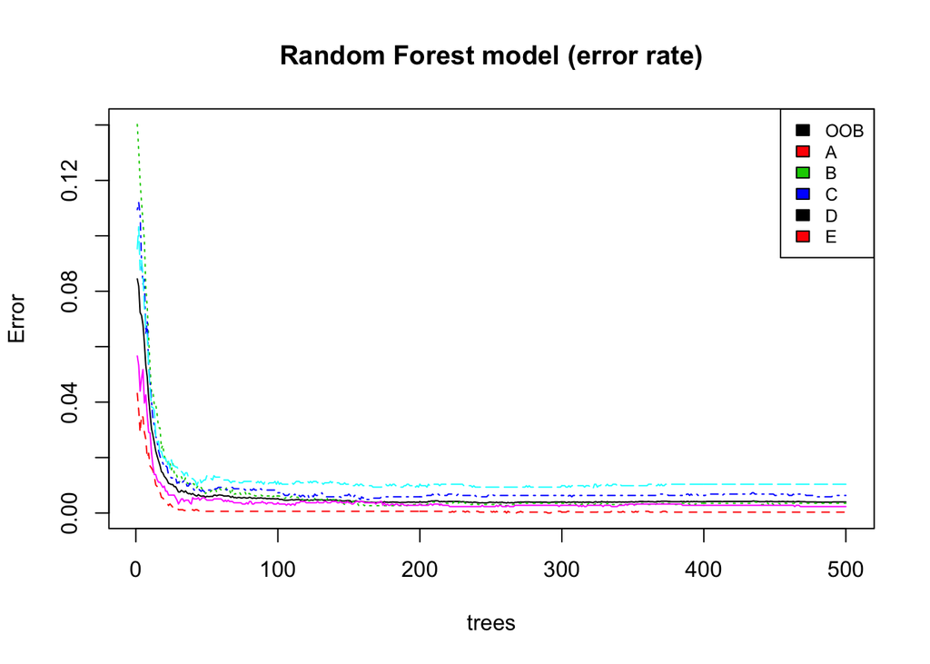

```r
plot(modFitRF,main="Random Forest model (error rate)")
legend("topright", colnames(modFitRF$err.rate),col=1:4,cex=0.8,fill=1:4)
```

### Predicting with boosting

```r
modFitB<-train(classe~.,data=newtraining, method="gbm",verbose=FALSE)
print(modFitB)
```

```
## Stochastic Gradient Boosting
##
## 11776 samples
##    53 predictor
##     5 classes: 'A', 'B', 'C', 'D', 'E'
##
## No pre-processing
## Resampling: Bootstrapped (25 reps)
##
## Summary of sample sizes: 11776, 11776, 11776, 11776, 11776, 11776, ...
##
## Resampling results across tuning parameters:
##
##   interaction.depth  n.trees  Accuracy   Kappa      Accuracy SD
##   1                   50      0.7576672  0.6923619  0.004897739
##   1                  100      0.8287223  0.7830761  0.005286337
##   1                  150      0.8672597  0.8319676  0.005444055
##   2                   50      0.8794332  0.8472703  0.005959732
##   2                  100      0.9353348  0.9181672  0.004957543
##   2                  150      0.9587187  0.9477644  0.002974130
##   3                   50      0.9280559  0.9089291  0.005358974
##   3                  100      0.9667876  0.9579747  0.003498170
##   3                  150      0.9822647  0.9775627  0.003082003
##   Kappa SD
##   0.006175466
##   0.006764647
##   0.006891704
##   0.007583957
##   0.006290185
##   0.003771634
##   0.006783958
##   0.004432257
##   0.003897865
##
## Tuning parameter 'shrinkage' was held constant at a value of 0.1
## Accuracy was used to select the optimal model using  the largest value.
## The final values used for the model were n.trees = 150,
##  interaction.depth = 3 and shrinkage = 0.1.
```

#### Ramdon Forest provided better results, compared with other used algorithms.